# Estimating a hierarchical model of CRRA utility function in R and Stan

James R Bland (https://sites.google.com/site/jamesbland/)

October 2, 2019

Earlier, I demonstrated [how to estimate a CRRA utility function using the choice data from just one subject](https://jamesblandecon.github.io/HR2009individual.html). This is fine, but usually, we want to say something about the *distribution* of subjects’ preferences, and this is where hierarchical models come in handy. Fortunately, once we have specified the model for one subject, it is relatively easy to modify our code to do this.

## Data

I am using the same freely available data from the following economic experiment:

> Harrison, Glenn W., and E. Elisabet Rutstrom. “Expected utility theory and prospect theory: One wedding and a decent funeral.” Experimental economics 12, no. 2 (2009): 133.

You can download the data from Glenn Harrison’s website (https://cear.gsu.edu/gwh/) here: http://cear.gsu.edu/files/2013/05/One-Wedding-and-a-Decent-Funeral1.zip. In particular, all we need is the Stata file `tmpLOTTERY.dta`. For this, I will be using the data from subjects in the “gains frame” of the experiment only. This is because we should expect subjects to behave differently if gambles are expressed in the loss frame, or some mixture of gains and losses. We could add these back in later, with more parameters, to test this explicitly, but for now I want to show you the simplest possible hierarchical model for this application.

## The model

I break the model specification down into two sections. First, I specify what’s happening at the individual level. This part is identical to [my previous example](https://jamesblandecon.github.io/HR2009individual.html). Then, I specify what is happening at the population level.

### Individual level

I assume that each subject is a constant relative risk aversion (CRRA) expected utility-maximizer with utility over certain monetary outcomes of $u_i(x)=x^{r_i}$, where $r_i$ is a parameter in sunject $i$’s utility function. Hence, they seek take the action $a$ that maximizes $E\left[X^{r_i}\mid a\right]$, where $X\mid a$ is the lottery induced by choosing action $a$. I assume that subjects use a logistic decision rule, so they are more likely to take actions that yield greater utility, but don’t always take the action that maximizes their utility. The parameter in logistic choice is $\lambda_i$, which measures subject $i$’s choice precision. Given these two parameters, subject $i$’s action $a_{i,t}$ is distributed:
$$a_{i,t} \mid r_i,\lambda_i \sim \mathrm{Bernoulli}\left(\lambda\left[E[X^{r_i }\mid L]-E[X^{r_i }\mid R]\right]\right)$$
where $L$ and $R$ are the “left” and “right” lotteries that the subject had to choose from at decision $t$.

### Population level

There are two individual-level parameters: $r_i$ and $\lambda_i$, both of which are restricted to be positive real numbers. Since the log-normal distribution ensures this restriction, I specify the following model for the distribution of risk aversion and choice precision:
$$\begin{aligned}
\log r_i&\sim iid\ N (\mu_r,\sigma_r^2)\\
\log \lambda_i&\sim iid\ N (\mu_\lambda,\sigma_\lambda^2)\\
\end{aligned}$$
Note that this looks almost exactly like the priors I specified in my previous example.

Here, I could have specified a multivariate normal model for $(r_i,\lambda_i)$. Then we would be able to say something about the correlation between these parameters, which might be somewhat interesting. Maybe I will write another post on this later.

## Coding up the model in Stan

```c
// HR2009Hierarchical.stan
functions {
   // User-defined functions go here. I don't have any for this application

}
data {
  // Tell Stan how to read in the data
  int<lower=0> ndecisions; // Number of observations
  int<lower=0> nsubj; // number of subjects
  real<lower=0,upper=1> PL[ndecisions,4]; // Left lottery
  real<lower=0,upper=1> PR[ndecisions,4]; // Right lottery
  int<lower=0,upper=1>  L[ndecisions]; // Choices (1=left)
  real<lower=0> prizes[ndecisions,4]; // prizes from lotteries
  int<lower=1,upper=nsubj> id[ndecisions]; // vector mapping decisions to subject ids
  real priorR[4];
  real priorL[4];

}
transformed data {
  // not needed here

}
parameters {
  // define and set bounds for the parameters of the model
  real rMU; // mean of log risk aversion
  real<lower=0> rSD; // standard deviation of log risk aversion
  real lMU; // mean of log choice precision
  real<lower=0> lSD; // standard deviation of log choice precision
  real<lower=0> r[nsubj]; // risk aversion
  real<lower=0> l[nsubj]; // Choice precision (lambda)


}
transformed parameters {
    // Some transformations (functions) of the parameters that I will be using
    real<lower=0> UL[ndecisions]; // Utility of left lottery
    real<lower=0> UR[ndecisions]; // Utility of right lottery
    real lDU[ndecisions]; // Utility difference * lambda





    // The equations for the utility of the left and right lotteries
    for (ii in 1:ndecisions) {
      UL[ii]  = PL[ii,1]*pow(prizes[ii,1],r[id[ii]])+PL[ii,2]*pow(prizes[ii,2],r[id[ii]])+PL[ii,3]*pow(prizes[ii,3],r[id[ii]])+PL[ii,4]*pow(prizes[ii,4],r[id[ii]]);//
      UR[ii]  = PR[ii,1]*pow(prizes[ii,1],r[id[ii]])+PR[ii,2]*pow(prizes[ii,2],r[id[ii]])+PR[ii,3]*pow(prizes[ii,3],r[id[ii]])+PR[ii,4]*pow(prizes[ii,4],r[id[ii]]);//
      lDU[ii] = l[id[ii]]*(UL[ii]-UR[ii]);
    }

}
model {
    // Priors
    rMU ~ normal(priorR[1],priorR[2]);
    rSD ~ gamma(priorR[3],priorR[4]);
    lMU ~ normal(priorL[1],priorL[2]);
    lSD ~ gamma(priorL[3],priorL[4]);
    // Hierarchical specification
    l ~ lognormal(lMU,lSD);
    r ~ lognormal(rMU,rSD);

    // Specify likelihood
    // lDU is the latent utility difference
    L ~ bernoulli_logit(lDU);

}
generated quantities {
    // Fraction of subjects who are risk averse
    //real<lower=0,upper=1> FracRiskAverse;
    //FracRiskAverse = normal_cdf (0 | rMU,rSD);
}
```

## Estimating the model in RStan

```r
# HR2009.R
rm(list=ls())
setwd("C:/Users/jbland/OneDrive - University of Toledo/General notes on structural Bayes/Structural_Individual")
library(foreign)
library(xtable)
library(ggplot2)
library(gganimate)
library("rstan") # observe startup messages
rstan_options(auto_write = TRUE)
Sys.setenv(LOCAL_CPPFLAGS = '-march=native')
options(mc.cores = parallel::detectCores())



FullData <- read.dta("tmpLOTTERY.dta")

# HR drop these observetions at the start of their lottery_Wedding.do file
FullData<-FullData[FullData$core==1,]
# I only want to focus on the gains frame here
Data<-FullData[FullData$Frame=="Gain Frame",]

# sort by id
Data<-Data[order(Data$id),]

PL<-as.matrix(data.frame(Data[,c("P0left","P1left","P2left","P3left")]))
PR<-as.matrix(data.frame(Data[,c("P0right","P1right","P2right","P3right")]))
prizes<-data.frame(Data[,c("prize0","prize1","prize2","prize3")])
prizes<-prizes-min(prizes)
prizes<-prizes/max(prizes)
prizes<-as.matrix(prizes)
L<-as.vector((as.integer(Data$choice=="L")))
idList<-unique(Data$id)
nsubj<-length(idList)
id<-Data$id
for (ii in 1:nsubj) {
  id[Data$id==idList[ii]]<-ii
}
ndecisions<-length(L)

# specify priors as data
# this way Stan doesn't have to re-compile if you change them
priorR<-c(log(0.6),3.66,0.25,0.5)
priorL<-c(2.63,0.1,0.25,0.5)

Sim<-stan("HR2009Hierarchical.stan")

# This file is a bit big (~600Mb), so I don't want to save it to Dropbox.
# I can always run the script again if I lose the output.
saveRDS(Sim,"C:/Users/jbland/Documents/CodeExampleFileDump/HR2009Hierarchical.Rds")
```

## Looking at the results

First let’s have a look at the population-level parameters

```r
Sim<-readRDS("HR2009Hierarchical.Rds")
SimSum<-summary(Sim)$summary
SimSum[c("rMU","rSD","lMU","lSD"),c("mean","sd")]
```

```
##           mean         sd
## rMU -0.9143010 0.11650985
## rSD  0.8020640 0.11276305
## lMU  2.8507992 0.08151004
## lSD  0.6616188 0.10525918
```

Remember that these are the parameters log-normal distributions, so median risk aversion is approximately:

```r
exp(SimSum[c("rMU"),c("mean")])
```

```
## [1] 0.4007967
```

But we can also look at the entire distribution of $r_i$, which is also function of $\mu_r$ and $\sigma_r$:

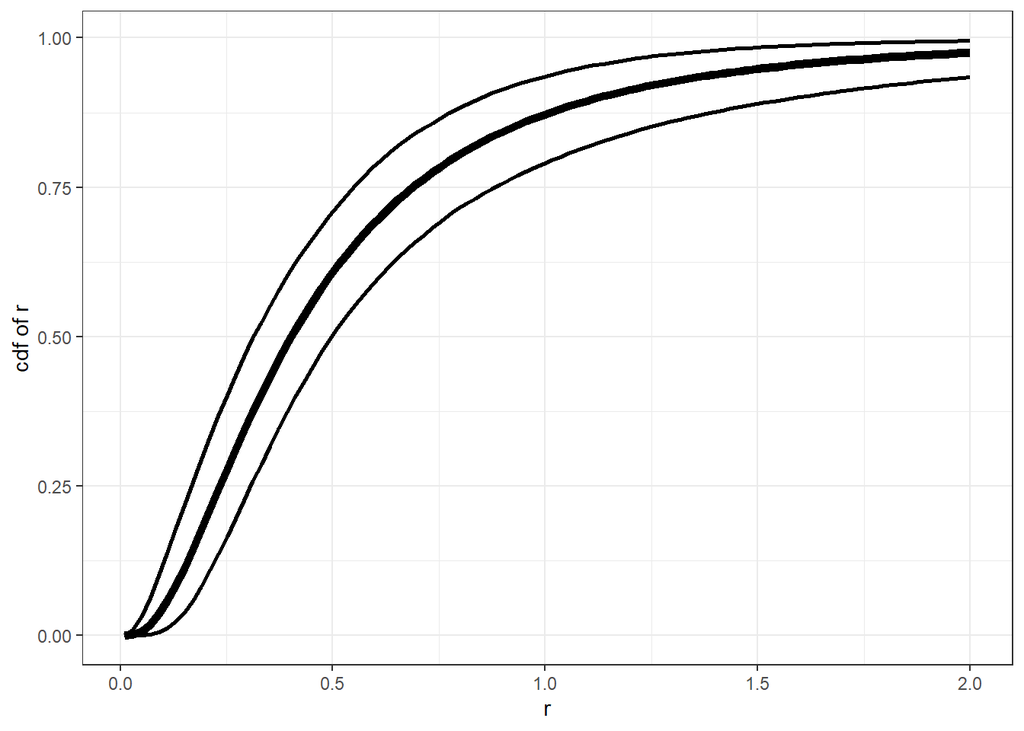

```r
rMU<-extract(Sim)$rMU
rSD<-extract(Sim)$rSD
RR<-seq(0.01,2,length=100)
cdf<-c()
for (ss in 1:length(rMU)) {
  cdf<-rbind(cdf,pnorm((log(RR)-rMU[ss])/rSD[ss]))
}

mcdf<-colMeans(cdf)
lcdf<-apply(cdf, 2, quantile, probs = c(0.025),  na.rm = TRUE)
rcdf<-apply(cdf, 2, quantile, probs = c(0.975),  na.rm = TRUE)

plt<-ggplot()+geom_line(size=2,aes(x=RR,y=mcdf))+geom_line(size=1,aes(x=RR,y=lcdf))+geom_line(size=1,aes(x=RR,y=rcdf))
plt<-plt+theme_bw()+xlab("r")+ylab("cdf of r")
plt
```

The thick line shows the posterior mean, and the thin lines show a 95% Bayesian credible region around the population cdf of r.

Of particular interest might be the fraction of people who are risk-averse, which is:

```r
fracRA<-pnorm(-rMU/rSD)
meanAndSD<-c(mean(fracRA),sqrt(var(fracRA)))
meanAndSD
```

```
## [1] 0.87236289 0.03751933
```

This is the posterior mean and standard deviation. Getting the latter is particularly hard in maximum likelihood because it involves bootstrapping and/or the delta method.

Finally, we can do all of the same things as we did before with the individual level parameters. For example, here are their posterior means:

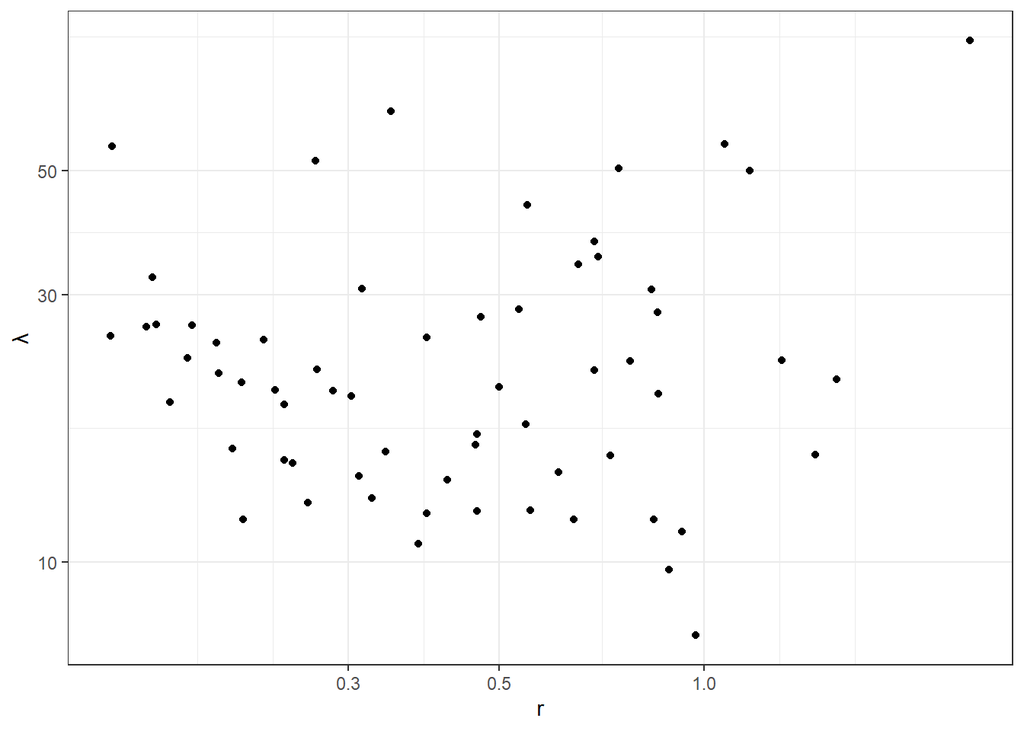

```r
rSummary<-summary(Sim,pars=c("r"))$summary[,c("mean","sd")]
lSummary<-summary(Sim,pars=c("l"))$summary[,c("mean","sd")]
D<-cbind(rSummary,lSummary)
colnames(D)<-c("rM","rSD","lM","lSD")
D<-data.frame(D)
plt<-ggplot(data=D,aes(x=rM,y=lM))+geom_point()+theme_bw()
plt<-plt+ scale_x_continuous(trans='log10')+scale_y_continuous(trans='log10')
plt<-plt+xlab("r")+ylab("\u03BB")
plt
```